# R Notebook

```r
rm(list=ls())
library(tidyverse)
library(readr)
library(mFilter)
library(lubridate)
```

Loading the data

```r
raw_data <- read.csv("C:/Users/benny/OneDrive/Documents/Teaching/Data and codes/Time series/costa_rica/costa_rica.csv", header=TRUE, sep=";")
```

```r
head(raw_data)
```

|  | Year | Inflation_rate | GDP |
| --- | --- | --- | --- |
| 1 | 1980 | 18.1 | 4854 |
| 2 | 1981 | 36.8 | 2636 |
| 3 | 1982 | 90.3 | 2619 |
| 4 | 1983 | 32.5 | 3162 |
| 5 | 1984 | 12.0 | 3678 |
| 6 | 1985 | 15.1 | 3941 |

```r
attach(raw_data)

raw_data$GDP <- as.double(raw_data$GDP)
str(raw_data)
```

```
## 'data.frame':    43 obs. of  3 variables:
##  $ Year          : int  1980 1981 1982 1983 1984 1985 1986 1987 1988 1989 ...
##  $ Inflation_rate: num  18.1 36.8 90.3 32.5 12 15.1 11.8 16.8 20.8 16.5 ...
##  $ GDP           : num  4854 2636 2619 3162 3678 ...
```

Calculating GDP Growth rate

```r
grw <- function(x){
  diff(log2(x))
}

raw_data <- raw_data[2:43,]  ## one can also use raw_data %>% filter(!row_number() %in% 1)
raw_data$GDP_growth <-grw(GDP)
```

Visualizing the time series plot (GDP growth and Inflation) using ggplot

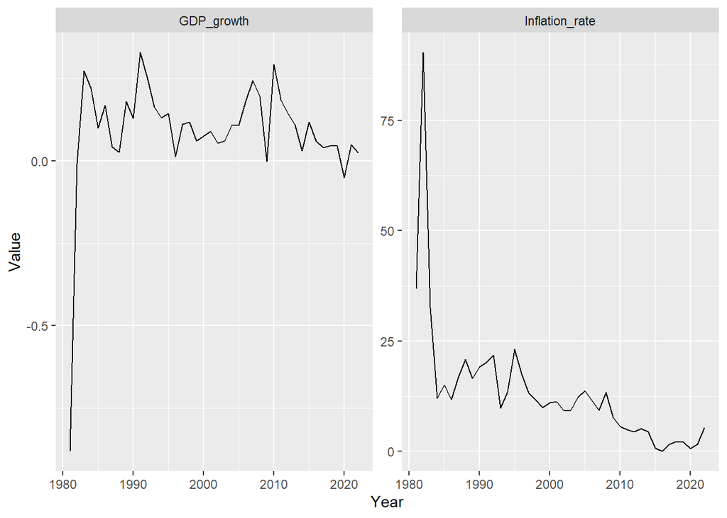

```r
#ggplot(raw_data, aes(Year, Inflation_rate))+ geom_line()+
#   xlab("Year")+ylab("Inflation")+ ggtitle("Inflation evolution - Costa Rica")


#ggplot(raw_data, aes(Year, GDP_growth))+ geom_line()+xlab("Year")+
#ylab("GDP_growth")+ ggtitle("Economic Growth - Costa Rica")


data_pivot <- raw_data%>% pivot_longer( !c(Year, GDP), names_to ="Economic_variables", values_to = "Value")
ggplot(data_pivot,aes(Year,Value))+ geom_line()+facet_wrap("Economic_variables",scales = "free")
```

Visualizing the correlation between inflation and growth. Using a linear fit (OLS) and a non-linear fit (GAM)

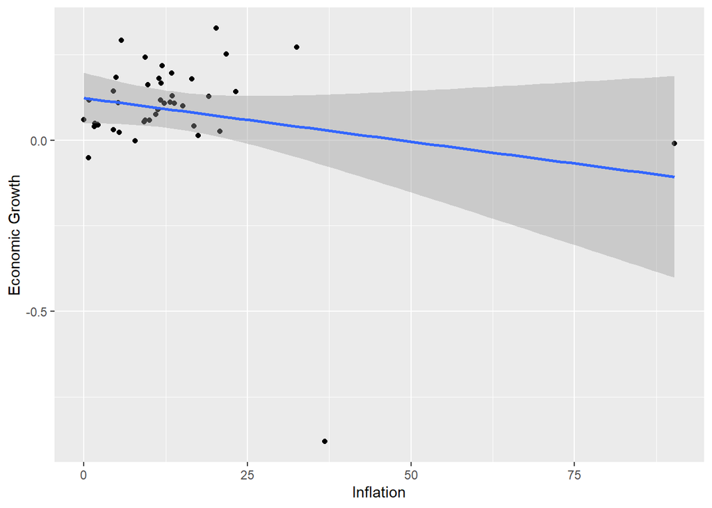

```r
ggplot(raw_data, aes( Inflation_rate, GDP_growth))+geom_point() +
  geom_smooth(method="lm") +xlab("Inflation")+ylab("Economic Growth")
```

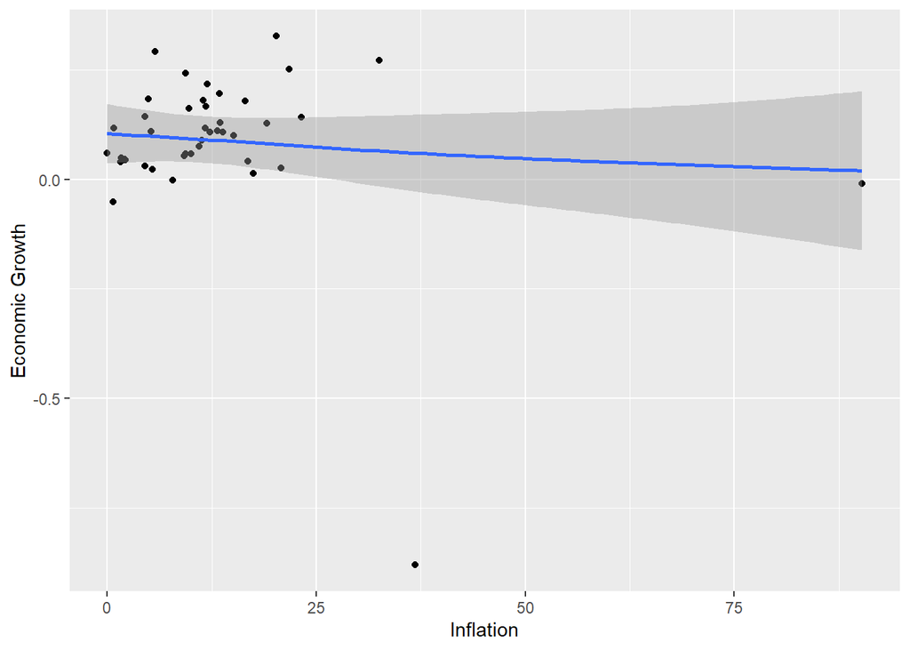

```r
ggplot(raw_data, aes( Inflation_rate, GDP_growth))+geom_point() +
 geom_smooth(method="gam") +xlab("Inflation")+ylab("Economic Growth")
```

Using HP filter to obtain long term trend from Inflation and economic growth package (mFilter). Firstly, we transform data into time series after which we extract the trend. Finally we crate a new data frame consisting of the trend inflation and trend growth

```r
library(mFilter)

Inflation_ts <- ts(raw_data$Inflation_rate, start=1981, frequency = 1)
GDP_growth_ts <- ts(raw_data$GDP_growth, start=1981, frequency = 1)

Inflation_hp <- mFilter(Inflation_ts, filter="HP")
Inflation_trend <- Inflation_hp$trend

GDP_hp <- mFilter(GDP_growth_ts , filter="HP")
GDP_trend <- GDP_hp$trend

data_new <- data.frame(cbind(Inflation_trend, GDP_trend))
```

The filtered trend from Inflation using Hp filter

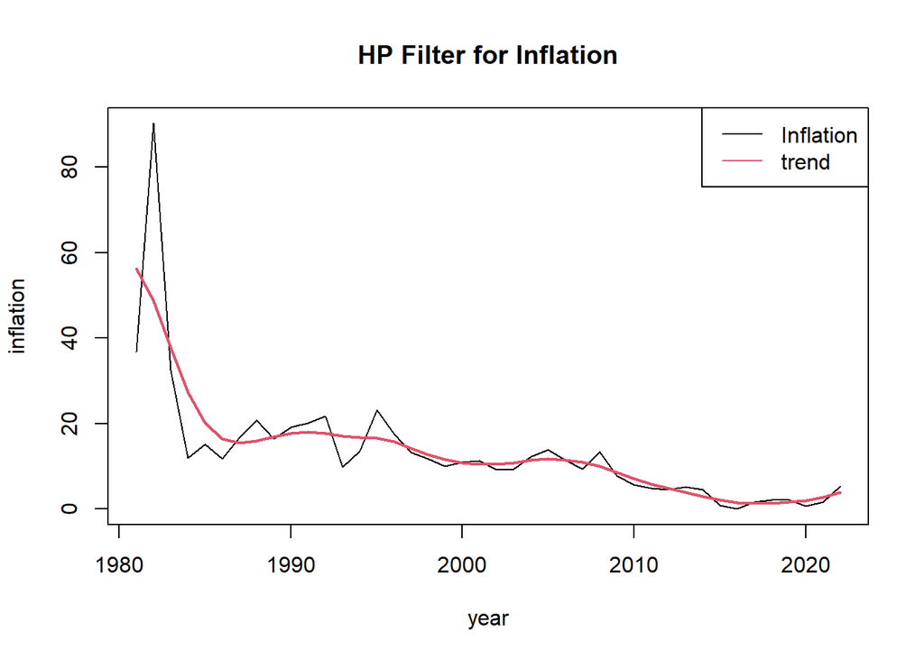

```r
plot(Inflation_ts,col=1, main = "HP Filter for Inflation", ylab="inflation", xlab="year")
lines(Inflation_trend, col=2, lwd=2)
legend("topright",legend=c( "Inflation", "trend"),col = 1:2,lty=1)
```

The filtered trend from GDP Growth using Hp filter

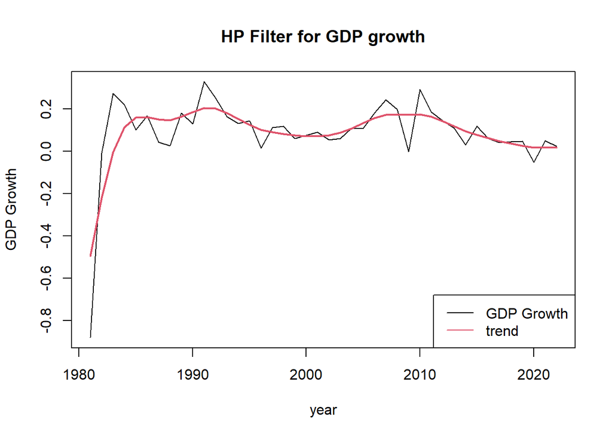

```r
plot(GDP_growth_ts,col=1, main = "HP Filter for GDP growth", ylab="GDP Growth", xlab="year")
lines(GDP_trend, col=2, lwd=2)
legend("bottomright",legend=c( "GDP Growth", "trend"),col = 1:2,lty=1)
```

Visualizing the correlation between the long term inflation and economic growth

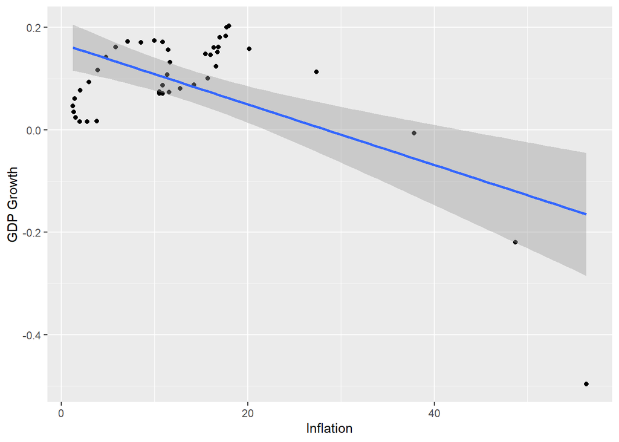

```r
ggplot(data_new, aes( Inflation_trend, GDP_trend))+geom_point() +
  geom_smooth(method="lm") +xlab("Inflation")+ylab("GDP Growth")
```

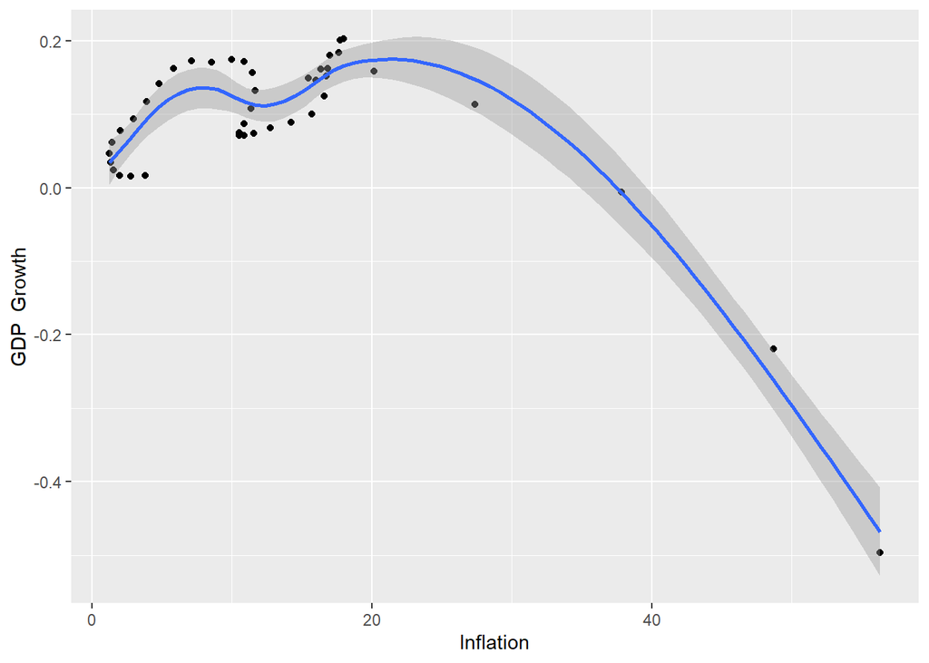

```r
ggplot(data_new, aes( Inflation_trend, GDP_trend))+geom_point() +
  geom_smooth(method="gam") +xlab("Inflation")+ylab("GDP  Growth")
```

Similarly, we use the Baxter and King filter to obtain the long run trend from inflation and growth

```r
Inflation_bk <- mFilter(Inflation_ts, filter="BK")
Inflation_bkt <- Inflation_bk$trend



GDP_bk <- mFilter(GDP_growth_ts, filter="BK")
GDP_bkt <- GDP_bk$trend

data_new1 <- as.data.frame(cbind(Inflation_bkt, GDP_bkt))
data_new1 <-na.omit(data_new1)
```

The filtered trend from Inflation using Baxter and king filter

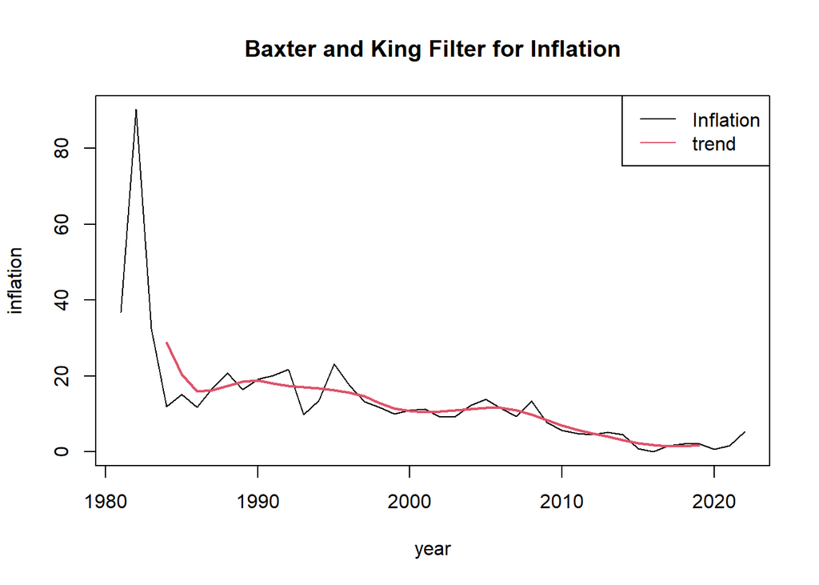

```r
plot(Inflation_ts,col=1, main = "Baxter and King Filter for Inflation", ylab="inflation", xlab="year")
lines(Inflation_bkt, col=2, lwd=2)
legend("topright",legend=c( "Inflation", "trend"),col = 1:2,lty=1)
```

The filtered trend from GDP Growth using Baxter and king filter

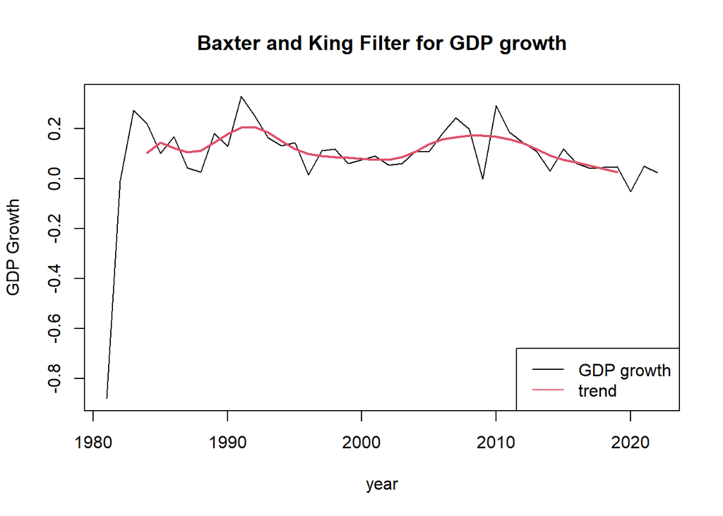

```r
plot(GDP_growth_ts,col=1, main = "Baxter and King Filter for GDP growth", ylab="GDP Growth", xlab="year")
lines(GDP_bkt, col=2, lwd=2)
legend("bottomright",legend=c( "GDP growth", "trend"),col = 1:2,lty=1)
```

Once again we visualize the long term relationship between inflation and growth

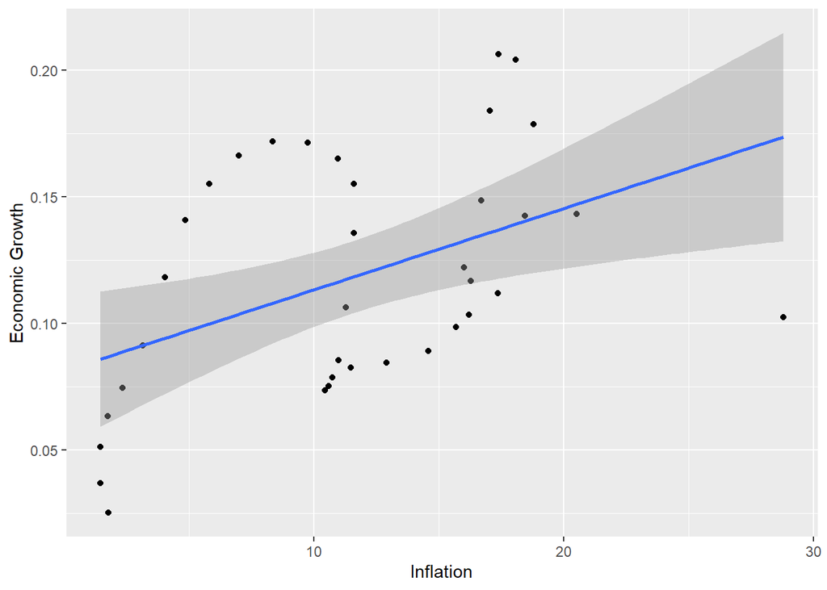

```r
ggplot(data_new1, aes( Inflation_bkt, GDP_bkt))+geom_point() +
  geom_smooth(method="lm") +xlab("Inflation")+ylab("Economic Growth")
```

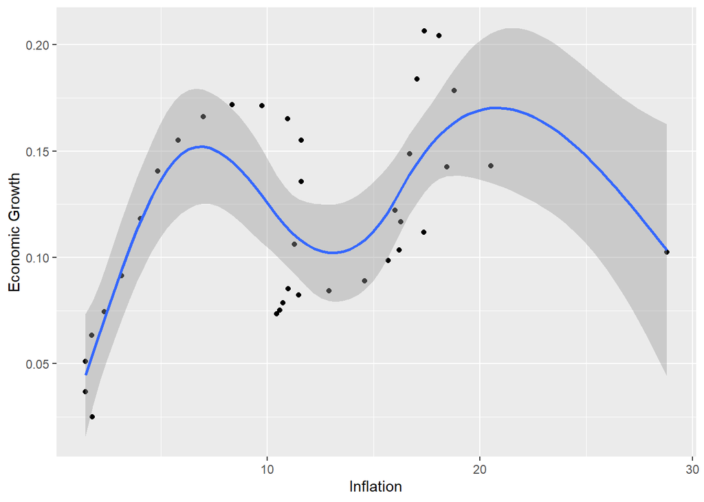

```r
ggplot(data_new1, aes( Inflation_bkt, GDP_bkt))+geom_point() +
  geom_smooth(method="gam") +xlab("Inflation")+ylab("Economic Growth")
```

we observe an oscilating relationship between the variable (positive at some point and negative at other points). This provides some indication of growth fatigue as inflation increases